# Análise de Média Variância

Bruno Tebaldi

21 de outubro de 2018

## Introdução

Vamos analisar o cenário de retorno de uma carteira com ativos de risco e ativos de renda fixa. Para isso vamos simular uma carteira com dois ativos de risco e um ativo de renda fixa.

## Setup

Para o exercicio vamos precisar de bibliotecas externas para melhor apresentar os dados.

```r
library(ggplot2)
library(tibble)
```

Vamos limpar qualquer variavel do sistema. Assim temos a garantia que estamos trabalhando somente com nossas variaveis

```r
# Limpa variaveis
rm(list=ls())
```

### Retornos

```r
# gera retorno para dois ativos com risco
R_p = c(10.33, 11.12)

# GEra o retornor de Renda Fixa
rf = 10

# Calcula o retorno líquido
R_net = R_p - rf
```

### Variancia

Determina a matrix de Variancia e covariancia para os ativos de risco.
$$\Omega = \begin{bmatrix}
245.862 & 120.148 \\
120.148 & 469.590
\end{bmatrix}$$

```r
# Determina a matrix de Variancia e covariancia para os ativos de risco
Omega = matrix(NA, ncol=2, nrow=2)
Omega[1,] = c(245.862, 120.148)
Omega[2,] = c(120.148, 469.590)
```

## Experimento

Vamos realizar $10^4$ experimentos. Para isso vamos sortear os pessos para os ativos de risco a partir de uma distribuicao normal padrão. Como a fronteira eficiente é importante para nos, vamos forçar que $10^3$ sorteios somem exatamente 1, e vamos forcar tambem que $10^3$ sorteios somem -1 (Seria o caso de se vender em vez de comprar).

```r
# Realiza o sorteio dos pesos de uma normal padrao
sampleSize = 1e4
weights = matrix(NA, ncol = 2, nrow=sampleSize)
weights[,1] = rnorm(sampleSize, mean = 0, sd = 1)
weights[,2] = rnorm(sampleSize, mean = 0, sd = 1)

# forca os pesos serem iguais a 1 e -1
n=1e3
weights[1:n,2] = 1-weights[1:n,1]
weights[n+1:n+n,2] = -1-weights[n+1:n+n,1]
```

Vamos adotar que o retorno da carteira é o portifolio ponderado. Logo temos:
$$R_{c} = R_{p}' w \\
Var_c = w'\Omega w$$

```r
R_c = matrix(NA, ncol = 1, nrow=sampleSize)
Var_c = matrix(NA, ncol = 1, nrow=sampleSize)

for (i in 1:sampleSize){
  w_i = as.matrix(weights[i,])

  R_c[i,1] = t(w_i) %*% R_net;
  Var_c[i,1] = t(w_i) %*% Omega %*% w_i
}
```

### Classificação

Vamos organizar os retornos classificando eles pelos pessos.

1. Pessos dos ativos > 1;
2. Pessos dos ativos = 1;
3. Pessos dos ativos entre 1 e 0;
4. Pessos dos ativos entre 0 e -1;
5. Pessos dos ativos = -1;
6. Pessos dos ativos < -1;

```r
# soma as linhas
RS = rowSums(weights)

# Organiza os dados em um data frame.
data = data.frame("Sdv"=Var_c^0.5,"Ret"=R_c, "Type" = NA)
data = as.tibble(data)

# classifica os dados
data[RS>1,3]= "[1, +]"
data[RS==1,3]= "=1"
data[RS<1,3]= "[0, 1]"
data[RS<0,3]= "[-1, 0)"
data[RS==-1,3]= "=-1"
data[RS< -1,3]= "[-, -1]"

# remove variaveis que nao serao mais utilizadas
rm(list = c("RS", "w_i"))

# cria os filtros de selecao
s1 = (data[,"Type"] == "[1, +]")
s2 = (data[,"Type"] == "=1")
s3 = (data[,"Type"] == "[0, 1]")
s4 = (data[,"Type"] == "[-1, 0)")
s5 = (data[,"Type"] == "=-1")
s6 = (data[,"Type"] == "[-, -1]")
```

## Plots

Vamos Agora plotar os graficos.

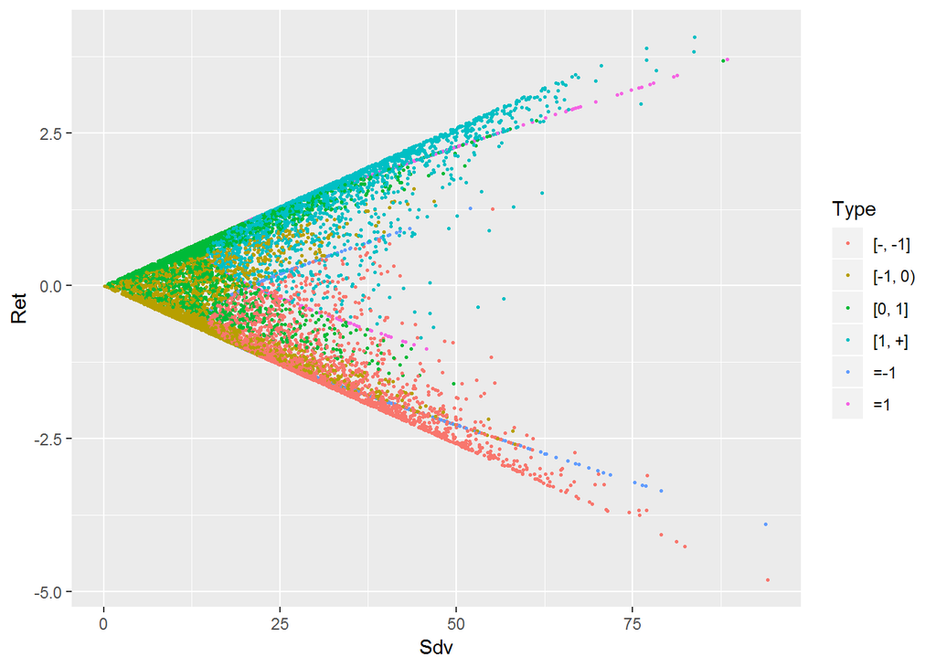

```r
ggplot(data, aes(x=Sdv, y=Ret, color=Type)) + geom_point(size=0.5)
```

Vamos analisar o caso de quando os pesos sao maiores do que 1

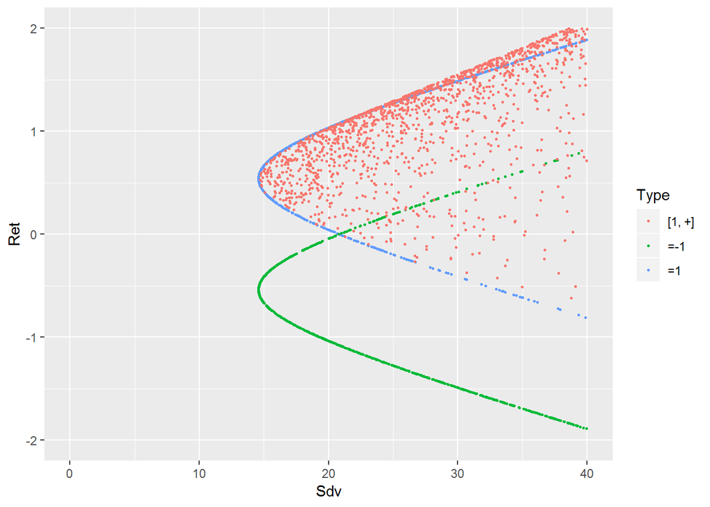

```r
ggplot(data[s1|s2|s5,], aes(x=Sdv, y=Ret, color=Type)) + geom_point(size=0.5) + ylim(c(-2,2))  + xlim(c(0,40))
```

Vamos analisar o caso de quando os pesos sao maiores do que 0 e menores do que 1

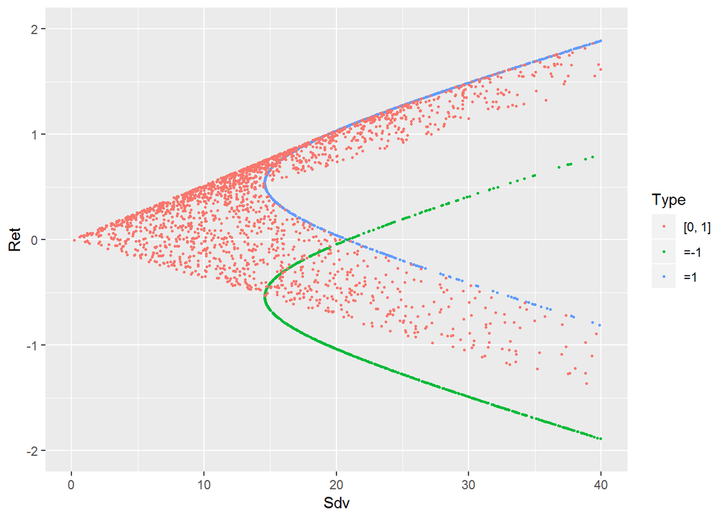

```r
ggplot(data[s3|s2|s5,], aes(x=Sdv, y=Ret, color=Type)) + geom_point(size=0.5) + ylim(c(-2,2))  + xlim(c(0,40))
```

Notem que a CAL é tangente a Fronteira eficiente

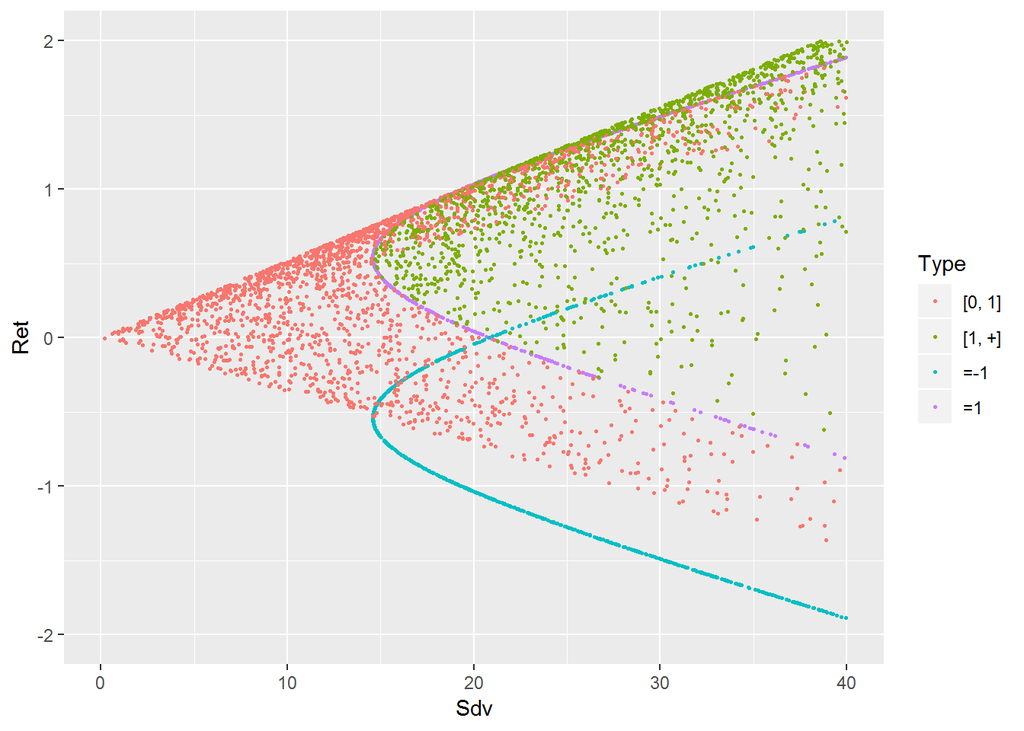

```r
ggplot(data[s1|s3|s2|s5,], aes(x=Sdv, y=Ret, color=Type)) + geom_point(size=0.5) + ylim(c(-2,2))  + xlim(c(0,40))
```

Analogamente temos fenomenos parecidos para os pesos negativos.

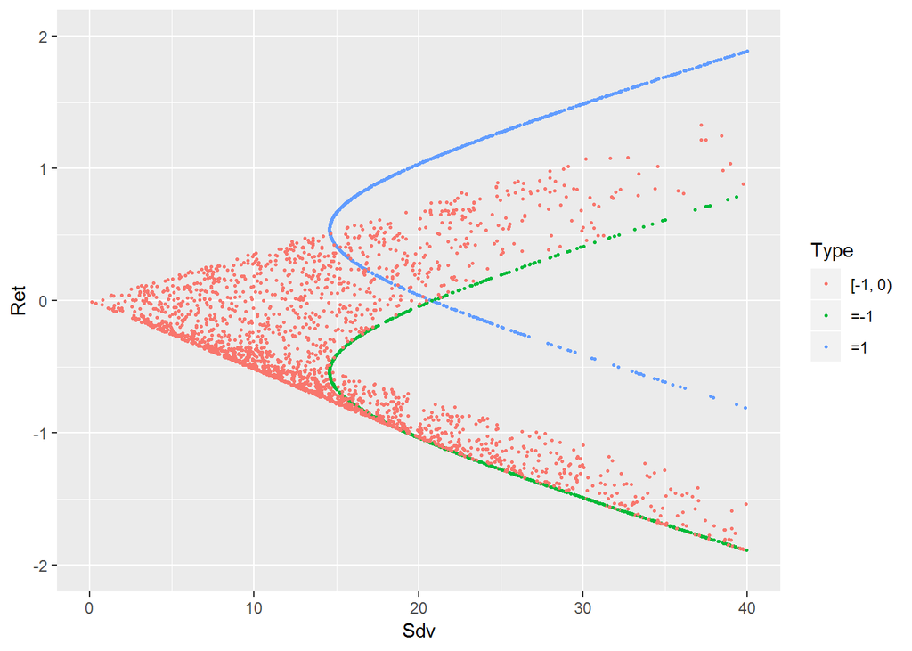

```r
ggplot(data[s4|s2|s5,], aes(x=Sdv, y=Ret, color=Type)) + geom_point(size=0.5) + ylim(c(-2,2))  + xlim(c(0,40))
```

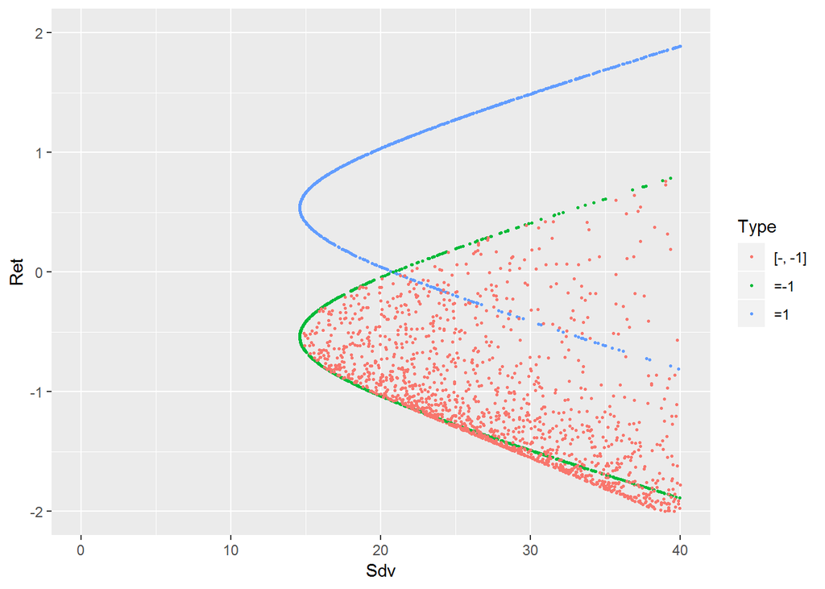

```r
ggplot(data[s6|s2|s5,], aes(x=Sdv, y=Ret, color=Type)) + geom_point(size=0.5) + ylim(c(-2,2))  + xlim(c(0,40))
```

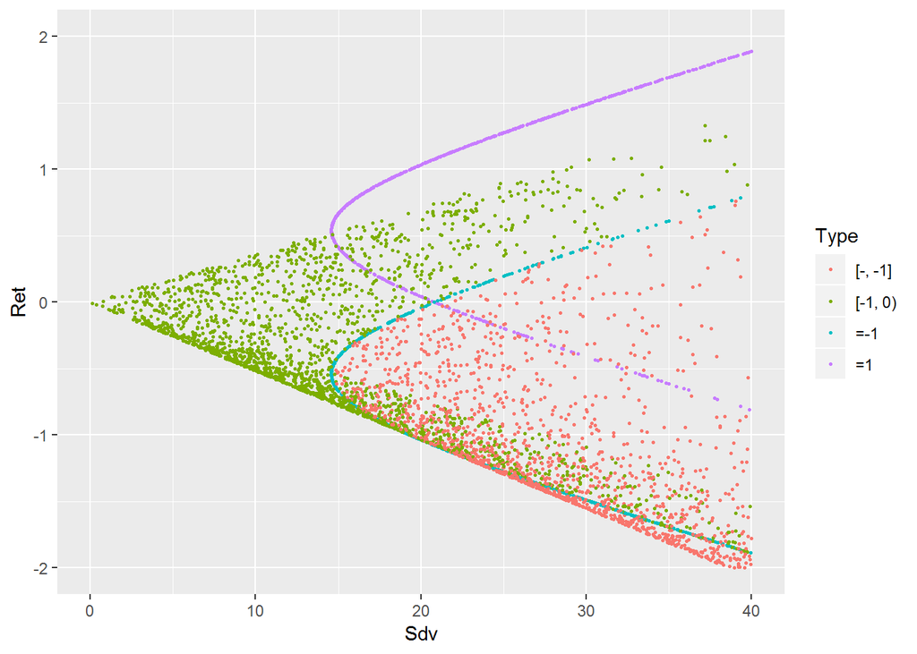

```r
ggplot(data[s4|s6|s2|s5,], aes(x=Sdv, y=Ret, color=Type)) + geom_point(size=0.5) + ylim(c(-2,2))  + xlim(c(0,40))
```